# Project1FifaDataAnalysis_MedhaRajashankar

Project Overview/Objectives:

Context:

In this project, we will be looking at FIFA's player data, which contains information such as personal details, wages, physical attributes, technical skills, potential, and positional strengths. This is preliminary data of FIFA 2018. Through this project, you will get a glimpse of insights into the beautiful game and the decisions a football manager goes through.

Objective:

Preliminary Data Analysis; Explore the dataset and practice extracting basic observations about the data. The idea is to get you comfortable with working in Python.

You are expected to :

Come up with the players' profiles (characteristics of a player) of the different teams/countries. Generate a set of insights and recommendations that will help the coach to understand the competition.

You are expected to perform the analysis to answer the following questions:

1. Prepare a rank-ordered list of the top 10 countries with the most players. List 5 countries that are producing the most numbers of footballers that play at this level?
2. Interpret the age after which a player stops improving.
3. Which type of offensive player tends to get paid the most: the striker, the right-winger, or the left-winger? Visualize through a scatter plot for all three.
4. Top 5 players for every preferred position in terms of overall as well as potential points. Who was the best in 2018?
5. Which club(s) has the maximum share of players from England? Which club(s) has the maximum share of players from Spain? Which club(s) have the maximum share of players from Germany?
6. As a National coach of the France team, you want to compare the national team of England, Spain, Italy, and Germany to understand the competition. The formation of the teams is restricted to 4-3-3 (4 defenders, 3 midfielders, 3 forwards, 1 Goal Keeper) and players with an overall value of more than 75 are preferred, now form the best team for each of the mentioned countries and compare them. Note down all the insights that you as a business analyst should share with the coach.

Data Dictionary ( Feature : Explanation )

- player index number : The index number of the player
- Name : name of a player
- Age : age of a player
- Photo : picture of player
- Nationality : player nationality
- Flag : Flag of team
- Overall : Overall Rating of the player
- Potential : Potential Rating of the player
- Club : The international club for which the player plays
- Club Logo : Logo of the club
- Value : The market value of the player in the transfer market
- Wage : Player Skills and other self-explanatory attributes
- Special : Player Skills and other self-explanatory attributes
- Acceleration : Player Skills and other self-explanatory attributes
- Aggression : Player Skills and other self-explanatory attributes
- Agility : Player Skills and other self-explanatory attributes
- Balance : Player Skills and other self-explanatory attributes
- Ball control : Player Skills and other self-explanatory attributes
- Composure : Player Skills and other self-explanatory attributes
- Crossing : Player Skills and other self-explanatory attributes
- Curve : Player Skills and other self-explanatory attributes
- Dribbling : Player Skills and other self-explanatory attributes
- Finishing : Player Skills and other self-explanatory attributes
- Free kick accuracy : Player Skills and other self-explanatory attributes
- GK diving : Player Skills and other self-explanatory attributes
- GK handling : Player Skills and other self-explanatory attributes
- GK kicking : Player Skills and other self-explanatory attributes
- GK positioning : Player Skills and other self-explanatory attributes
- GK reflexes : Player Skills and other self-explanatory attributes
- Heading accuracy : Player Skills and other self-explanatory attributes
- Interceptions : Player Skills and other self-explanatory attributes
- Jumping : Player Skills and other self-explanatory attributes
- Long passing : Player Skills and other self-explanatory attributes
- Long shots : Player Skills and other self-explanatory attributes
- Marking : Player Skills and other self-explanatory attributes
- Penalties : Player Skills and other self-explanatory attributes
- Positioning : Player Skills and other self-explanatory attributes
- Reactions : Player Skills and other self-explanatory attributes
- Short passing : Player Skills and other self-explanatory attributes
- Shot power : Player Skills and other self-explanatory attributes
- Sliding tackle : Player Skills and other self-explanatory attributes
- Sprint speed : Player Skills and other self-explanatory attributes
- Stamina : Player Skills and other self-explanatory attributes
- Standing tackle : Player Skills and other self-explanatory attributes
- Strength : Player Skills and other self-explanatory attributes
- Vision : Player Skills and other self-explanatory attributes
- Volleys : Player Skills and other self-explanatory attributes
- CAM : Center Attacking Midfielder
- CB : Center Back
- CDM : Center Defensive Midfielder
- CF : Center Forward
- CM : Center Midfielder
- ID : Player's ID in FIFA18
- LAM : Left Attacking Midfielder
- LB : Left Back
- LCB : Left Center Back
- LCM : Left Center Midfielder
- LDM : Left Defensive Midfielder
- LF : Left Forward
- LM : Left Midfielder
- LS : Left Striker
- LW : Left-Wing
- LWB : Left-Wing Back
- Preferred Positions : Player's Preferred Position
- RAM : Right Attacking Midfielder
- RB : Right Back
- RCB : Right Center Back
- RCM : Right Center Midfielder
- RDM : Right Defensive Midfielder
- RF : Right Forward
- RM : Right Midfielder
- RS : Right Striker
- RW : Right Wing
- RWB : Right Wing Back
- ST : Striker

Scoring Rubric & Best Practices for Notebook

- The notebook should be well-documented, with inline comments explaining the functionality of code and markdown cells containing comments on the observations and insights.
- The notebook should be run from start to finish in a sequential manner before submission.
- It is preferable to remove all warnings and errors before submission. The notebook should be submitted as an HTML file (.html) and NOT as a notebook file (.ipynb).
1. Prepare a rank ordered list: Prepare a rank-ordered list of the top 10 countries with the most players. List 5 countries that are producing the most numbers of footballers that play at this level. (4 points)
2. Interpret a particular age: Interpret the age after which a player stops improving. (4 points)
3. Analysis of offensive players: Which type of offensive players tends to get paid the most: the striker, the right-winger, or the left-winger? Visualize through a scatter plot for all three. (6 points)
4. Best players for 2018: Top 5 players for every preferred position in terms of overall as well as potential points. Who were the best in 2018? (6 points)
5. Analysis of different players and clubs: Which club(s) have the maximum share of players from England? Which club(s) have the maximum share of players from Spain? Which club(s) have the maximum share of players from Germany? (6 points)
6. Formation of best team and provide insights: As a National coach of the France team, you want to compare the national team of England, Spain, Italy, and Germany to understand the competition. The formation of the teams is restricted to 4-3-3 (4 defenders, 3 midfielders, 3 forwards, 1 Goal Keeper) and players with an overall value of more than 75 are preferred, now form the best team for each of the mentioned countries and compare them. Note down all the insights that you as a business analyst should share with the coach. (10 points)
7. Well commented Python Code: Structure and flow - Well commented code (4 points)

```python
# Command to ignore warnings

import warnings
warnings.filterwarnings("ignore")
```

```python
# Importing all of the required libraries

import numpy as np
import pandas as pd

import matplotlib.pyplot as plt
%matplotlib inline
import seaborn as sns
```

```python
# Loading the data set
pd.set_option('display.max_columns', None)

from google.colab import files
data_to_load = files.upload()
```

```
Saving FIFA.xlsx to FIFA (6).xlsx
```

```python
import io
df = pd.read_excel(io.BytesIO(data_to_load['FIFA.xlsx']))
```

```python
# Checking the shape of the data set

print(f'There are {df.shape[0]} rows and {df.shape[1]} columns.')
```

```
There are 17981 rows and 74 columns.
```

```python
df.info()
```

```
<class 'pandas.core.frame.DataFrame'>
RangeIndex: 17981 entries, 0 to 17980
Data columns (total 74 columns):
 #   Column               Non-Null Count  Dtype
---  ------               --------------  -----
 0   Unnamed: 0           17981 non-null  int64
 1   Name                 17981 non-null  object
 2   Age                  17981 non-null  int64
 3   Photo                17981 non-null  object
 4   Nationality          17981 non-null  object
 5   Flag                 17981 non-null  object
 6   Overall              17981 non-null  int64
 7   Potential            17981 non-null  int64
 8   Club                 17733 non-null  object
 9   Club Logo            17981 non-null  object
```

[output cut: 66 more lines]

Datatype Observations

- There are 5 columns in the dataset with the datatype of int. (Unnamed: 0, Age, Overall, Potential, Special).
- There are 26 columns in the dataset with the datatype of float. (CAM, CB, CDM, CF, CM, LAM, LB, LCB, LCM, LDM, LF, LM, LS, LW, LWB, RAM, RB, RCB, RCM, RDM, RF, RM, RS, RW, RWB, ST).
- There are 43 columns in the dataset with the data type of object which we will have to treat. (Name, Photo, Nationality, Flag, Club, Club Logo, Value, Wage, Acceleration, Aggression, Agility, Balance, Ball control, Composure, Crossing, Curve, Dribbling, Finishing, Free kick accuracy, GK diving, GK handling, GK kicking, GK positioning, GK reflexes, Heading accuracy, Interceptions, Jumping, Long passing, Long shots, Marking, Penalties, Positioning, Reactions, Short passing, Shot power, Sliding tackle, Sprint speed, Stamina, Standing tackle, Strength, Vision, Volleys, Preferred Positions).

Missing/Null Value Observations:

- There are 26 columns in the dataset with missing/null values which we will have to treat. ( CAM, CB, CDM, CF, CM, LAM, LB, LCB, LCM, LDM, LF, LM, LS, LW, LWB, RAM, RB, RCB, RCM, RDM, RF, RM, RS, RW, RWB, ST).
- All of the columns with missing/null values seem to have the same number of values missing (2,029 missing values).

```python
# Checking for duplicate entries in the data set

df.duplicated().sum()
```

```
0
```

```python
# Initial look at the dataset

np.random.seed(1)
df.sample(n=10)
```

|  | Unnamed: 0 | Name | Age | Photo | Nationality | Flag | Overall | Potential | Club | Club Logo | Value | Wage | Special | Acceleration | Aggression | Agility | Balance | Ball control | Composure | Crossing | Curve | Dribbling | Finishing | Free kick accuracy | GK diving | GK handling | GK kicking | GK positioning | GK reflexes | … |
| --- | --- | --- | --- | --- | --- | --- | --- | --- | --- | --- | --- | --- | --- | --- | --- | --- | --- | --- | --- | --- | --- | --- | --- | --- | --- | --- | --- | --- | --- | --- |
| 17167 | 17167 | N. Leighton | 18 | https://cdn.sofifa.org/48/18/players/238258.png | England | https://cdn.sofifa.org/flags/14.png | 54 | 68 | Millwall | https://cdn.sofifa.org/24/18/teams/97.png | 140K | 3K | 1299 | 67 | 49 | 52 | 56 | 51 | 48 | 24 | 26 | 48 | 55 | 25 | 11 | 11 | 9 | 13 | 12 | … |
| 4126 | 4126 | I. Hayden | 22 | https://cdn.sofifa.org/48/18/players/206115.png | England | https://cdn.sofifa.org/flags/14.png | 71 | 79 | Newcastle United | https://cdn.sofifa.org/24/18/teams/13.png | 3M | 32K | 1753 | 59 | 75 | 60 | 61 | 71 | 62 | 43 | 45 | 64 | 47 | 38 | 9 | 15 | 8 | 8 | 12 | … |
| 8268 | 8268 | F. Öztorun | 30 | https://cdn.sofifa.org/48/18/players/143751.png | Turkey | https://cdn.sofifa.org/flags/48.png | 67 | 67 | Atiker Konyaspor | https://cdn.sofifa.org/24/18/teams/101033.png | 550K | 10K | 1710 | 66 | 61 | 72 | 63 | 61 | 67 | 62 | 47 | 66 | 41 | 33 | 16 | 16 | 16 | 16 | 6 | … |
| 4822 | 4822 | Jair | 28 | https://cdn.sofifa.org/48/18/players/202487.png | Brazil | https://cdn.sofifa.org/flags/54.png | 71 | 71 | Jeonnam Dragons | https://cdn.sofifa.org/24/18/teams/1475.png | 2.4M | 7K | 1828 | 76 | 45 | 82 | 68 | 72 | 65 | 68 | 68 | 72 | 76 | 69 | 10 | 14 | 14 | 13 | 7 | … |
| 9017 | 9017 | Lee Gwang Hyeok | 21 | https://cdn.sofifa.org/48/18/players/221756.png | Korea Republic | https://cdn.sofifa.org/flags/167.png | 66 | 73 | Pohang Steelers | https://cdn.sofifa.org/24/18/teams/1474.png | 925K | 3K | 1665 | 84 | 63 | 71 | 90 | 68 | 55 | 62 | 50 | 68 | 55 | 50 | 7 | 8 | 10 | 12 | 14 | … |
| 10960 | 10960 | Luís Ribeiro | 25 | https://cdn.sofifa.org/48/18/players/220432.png | Portugal | https://cdn.sofifa.org/flags/38.png | 64 | 68 | Estoril Praia | https://cdn.sofifa.org/24/18/teams/10020.png | 425K | 2K | 1085 | 53 | 31 | 60 | 50 | 19 | 46 | 13 | 12 | 18 | 12 | 11 | 67 | 63 | 55 | 58 | 66 | … |
| 12130 | 12130 | Edardynho Neto | 25 | https://cdn.sofifa.org/48/18/players/230444.png | Brazil | https://cdn.sofifa.org/flags/54.png | 63 | 63 | Atlético Clube Goianiense | https://cdn.sofifa.org/24/18/teams/112119.png | 325K | 2K | 1604 | 68 | 67 | 74 | 58 | 58 | 60 | 36 | 38 | 54 | 42 | 32 | 8 | 9 | 16 | 11 | 8 | … |
| 9783 | 9783 | K. Risgård | 34 | https://cdn.sofifa.org/48/18/players/138729.png | Denmark | https://cdn.sofifa.org/flags/13.png | 66 | 66 | Aalborg BK | https://cdn.sofifa.org/24/18/teams/820.png | 325K | 5K | 1810 | 55 | 62 | 64 | 69 | 68 | 55 | 56 | 67 | 63 | 63 | 66 | 11 | 11 | 11 | 10 | 14 | … |
| 3862 | 3862 | I. Chochev | 24 | https://cdn.sofifa.org/48/18/players/224202.png | Bulgaria | https://cdn.sofifa.org/flags/9.png | 72 | 78 | Palermo | https://cdn.sofifa.org/24/18/teams/1843.png | 4.2M | 3K | 1860 | 50 | 63 | 57 | 51 | 75 | 64 | 61 | 62 | 73 | 60 | 55 | 7 | 9 | 14 | 14 | 12 | … |
| 13839 | 13839 | M. Nocciolini | 28 | https://cdn.sofifa.org/48/18/players/239678.png | Italy | https://cdn.sofifa.org/flags/27.png | 61 | 61 | Parma | https://cdn.sofifa.org/24/18/teams/50.png | 250K | 1K | 1481 | 74 | 38 | 58 | 59 | 65 | 55 | 59 | 48 | 68 | 67 | 34 | 14 | 12 | 11 | 8 | 5 | … |

Observation: We will need to remove the 'K' and 'M' from the entries in the Value and Wage columns and adjust the values accordingly.

```python
# Dropping the Unnamed: 0, Photo, Flag Photo, and Club Logo columns because they will not be necessary for the analysis

df.drop(['Unnamed: 0'], axis=1, inplace=True)
df.drop(['Photo'], axis=1, inplace=True)
df.drop(['Flag'], axis=1, inplace=True)
df.drop(['Club Logo'], axis=1, inplace=True)
```

```python
# Ensuring the columns have been dropped

print(f'There are {df.shape[0]} rows and {df.shape[1]} columns.')
```

```
There are 17981 rows and 70 columns.
```

```python
# Checking our changes

df.info()
```

```
<class 'pandas.core.frame.DataFrame'>
RangeIndex: 17981 entries, 0 to 17980
Data columns (total 70 columns):
 #   Column               Non-Null Count  Dtype
---  ------               --------------  -----
 0   Name                 17981 non-null  object
 1   Age                  17981 non-null  int64
 2   Nationality          17981 non-null  object
 3   Overall              17981 non-null  int64
 4   Potential            17981 non-null  int64
 5   Club                 17733 non-null  object
 6   Value                17981 non-null  object
 7   Wage                 17981 non-null  object
 8   Special              17981 non-null  int64
 9   Acceleration         17981 non-null  object
```

[output cut: 62 more lines]

Overall Inital Observations

- We now have 40 columns in the dataset with the data type of object which we will have to treat. (Name, Nationality, Club, Value, Wage, Acceleration, Aggression, Agility, Balance, Ball control, Composure, Crossing, Curve, Dribbling, Finishing, Free kick accuracy, GK diving, GK handling, GK kicking, GK positioning, GK reflexes, Heading accuracy, Interceptions, Jumping, Long passing, Long shots, Marking, Penalties, Positioning, Reactions, Short passing, Shot power, Sliding tackle, Sprint speed, Stamina, Standing tackle, Strength, Vision, Volleys, Preferred Positions).
- There are 4 columns in the dataset with the datatype of int. (Age, Overall, Potential, Special).
- There are 26 columns in the dataset with the datatype of float. (CAM, CB, CDM, CF, CM, LAM, LB, LCB, LCM, LDM, LF, LM, LS, LW, LWB, RAM, RB, RCB, RCM, RDM, RF, RM, RS, RW, RWB, ST).
- There are 26 columns in the dataset with missing/null values which we will have to treat. ( CAM, CB, CDM, CF, CM, LAM, LB, LCB, LCM, LDM, LF, LM, LS, LW, LWB, RAM, RB, RCB, RCM, RDM, RF, RM, RS, RW, RWB, ST).
- All of the columns with missing/null values seem to have the same number of valus missing (2,029 missing values).
- We will need to remove the 'K' and 'M' from the entries in the Value and Wage columns and adjust the values accordingly.

```python
# Function to remove units from the Value and Wage column values, adjust accordingly, and make numerical.

def makenumerical(entryvalue):
    if isinstance(entryvalue, str):  # checks if `income_val` is a string
        multiplier = 1  # handles K vs M salaries
        if entryvalue.endswith('K'):
            multiplier = 1000
        elif entryvalue.endswith('M'):
            multiplier = 1000000
        return float(entryvalue.replace('K', '').replace('M', '')) * multiplier
    else:  # this happens when the current income is np.nan
        return np.nan
```

```python
# Treating the Value and Wage columns using the makenumerical method just created

df['Value'] = df['Value'].apply(makenumerical)
df['Wage'] = df['Wage'].apply(makenumerical)
```

```python
# Checking our changes

df.head()
```

|  | Name | Age | Nationality | Overall | Potential | Club | Value | Wage | Special | Acceleration | Aggression | Agility | Balance | Ball control | Composure | Crossing | Curve | Dribbling | Finishing | Free kick accuracy | GK diving | GK handling | GK kicking | GK positioning | GK reflexes | Heading accuracy | Interceptions | Jumping | Long passing | … |
| --- | --- | --- | --- | --- | --- | --- | --- | --- | --- | --- | --- | --- | --- | --- | --- | --- | --- | --- | --- | --- | --- | --- | --- | --- | --- | --- | --- | --- | --- | --- |
| 0 | Cristiano Ronaldo | 32 | Portugal | 94 | 94 | Real Madrid CF | 95500000.0 | 565000.0 | 2228 | 89 | 63 | 89 | 63 | 93 | 95 | 85 | 81 | 91 | 94 | 76 | 7 | 11 | 15 | 14 | 11 | 88 | 29 | 95 | 77 | … |
| 1 | L. Messi | 30 | Argentina | 93 | 93 | FC Barcelona | 105000000.0 | 565000.0 | 2154 | 92 | 48 | 90 | 95 | 95 | 96 | 77 | 89 | 97 | 95 | 90 | 6 | 11 | 15 | 14 | 8 | 71 | 22 | 68 | 87 | … |
| 2 | Neymar | 25 | Brazil | 92 | 94 | Paris Saint-Germain | 123000000.0 | 280000.0 | 2100 | 94 | 56 | 96 | 82 | 95 | 92 | 75 | 81 | 96 | 89 | 84 | 9 | 9 | 15 | 15 | 11 | 62 | 36 | 61 | 75 | … |
| 3 | L. SuÃ¡rez | 30 | Uruguay | 92 | 92 | FC Barcelona | 97000000.0 | 510000.0 | 2291 | 88 | 78 | 86 | 60 | 91 | 83 | 77 | 86 | 86 | 94 | 84 | 27 | 25 | 31 | 33 | 37 | 77 | 41 | 69 | 64 | … |
| 4 | M. Neuer | 31 | Germany | 92 | 92 | FC Bayern Munich | 61000000.0 | 230000.0 | 1493 | 58 | 29 | 52 | 35 | 48 | 70 | 15 | 14 | 30 | 13 | 11 | 91 | 90 | 95 | 91 | 89 | 25 | 30 | 78 | 59 | … |

```python
# Checking our changes

df.info()
```

```
<class 'pandas.core.frame.DataFrame'>
RangeIndex: 17981 entries, 0 to 17980
Data columns (total 70 columns):
 #   Column               Non-Null Count  Dtype
---  ------               --------------  -----
 0   Name                 17981 non-null  object
 1   Age                  17981 non-null  int64
 2   Nationality          17981 non-null  object
 3   Overall              17981 non-null  int64
 4   Potential            17981 non-null  int64
 5   Club                 17733 non-null  object
 6   Value                17725 non-null  float64
 7   Wage                 17733 non-null  float64
 8   Special              17981 non-null  int64
 9   Acceleration         17981 non-null  object
```

[output cut: 62 more lines]

- The units have been removed from the entries in the Wage and Value columns and the values have been adjusted accordingly to the multiplier. The Wage and Value columns now have the datatype of float.
- We now have 38 columns in the dataset with the data type of object which we will have to treat. (Name, Nationality, Club, Acceleration, Aggression, Agility, Balance, Ball control, Composure, Crossing, Curve, Dribbling, Finishing, Free kick accuracy, GK diving, GK handling, GK kicking, GK positioning, GK reflexes, Heading accuracy, Interceptions, Jumping, Long passing, Long shots, Marking, Penalties, Positioning, Reactions, Short passing, Shot power, Sliding tackle, Sprint speed, Stamina, Standing tackle, Strength, Vision, Volleys, Preferred Positions).
- There are 26 columns in the dataset with missing/null values which we will have to treat. ( CAM, CB, CDM, CF, CM, LAM, LB, LCB, LCM, LDM, LF, LM, LS, LW, LWB, RAM, RB, RCB, RCM, RDM, RF, RM, RS, RW, RWB, ST). All of the columns with missing/null values seem to have the same number of values missing (2,029 missing values).

```python
df.isnull().sum()
```

```
Name              0
Age               0
Nationality       0
Overall           0
Potential         0
               ...
RM             2029
RS             2029
RW             2029
RWB            2029
ST             2029
Length: 70, dtype: int64
```

```python
df.loc[df['CAM'].isnull()==True]
```

|  | Name | Age | Nationality | Overall | Potential | Club | Value | Wage | Special | Acceleration | Aggression | Agility | Balance | Ball control | Composure | Crossing | Curve | Dribbling | Finishing | Free kick accuracy | GK diving | GK handling | GK kicking | GK positioning | GK reflexes | Heading accuracy | Interceptions | Jumping | Long passing | … |
| --- | --- | --- | --- | --- | --- | --- | --- | --- | --- | --- | --- | --- | --- | --- | --- | --- | --- | --- | --- | --- | --- | --- | --- | --- | --- | --- | --- | --- | --- | --- |
| 4 | M. Neuer | 31 | Germany | 92 | 92 | FC Bayern Munich | 61000000.0 | 230000.0 | 1493 | 58 | 29 | 52 | 35 | 48 | 70 | 15 | 14 | 30 | 13 | 11 | 91 | 90 | 95 | 91 | 89 | 25 | 30 | 78 | 59 | … |
| 6 | De Gea | 26 | Spain | 90 | 92 | Manchester United | 64500000.0 | 215000.0 | 1458 | 57 | 38 | 60 | 43 | 42 | 64 | 17 | 21 | 18 | 13 | 19 | 90 | 85 | 87 | 86 | 90 | 21 | 30 | 67 | 51 | … |
| 12 | T. Courtois | 25 | Belgium | 89 | 92 | Chelsea | 59000000.0 | 190000.0 | 1282 | 46 | 23 | 61 | 45 | 23 | 52 | 14 | 19 | 13 | 14 | 11 | 85 | 91 | 69 | 86 | 88 | 13 | 15 | 68 | 31 | … |
| 18 | G. Buffon | 39 | Italy | 89 | 89 | Juventus | 4500000.0 | 110000.0 | 1335 | 49 | 38 | 55 | 49 | 28 | 70 | 13 | 20 | 26 | 15 | 13 | 89 | 88 | 74 | 90 | 84 | 13 | 28 | 75 | 35 | … |
| 20 | J. Oblak | 24 | Slovenia | 88 | 93 | AtlÃ©tico Madrid | 57000000.0 | 82000.0 | 1290 | 43 | 34 | 67 | 49 | 16 | 55 | 13 | 13 | 12 | 11 | 14 | 84 | 90 | 77 | 87 | 84 | 15 | 19 | 76 | 26 | … |
| ... | ... | ... | ... | ... | ... | ... | ... | ... | ... | ... | ... | ... | ... | ... | ... | ... | ... | ... | ... | ... | ... | ... | ... | ... | ... | ... | ... | ... | ... | … |
| 17945 | A. Dillon | 20 | Republic of Ireland | 48 | 61 | Blackburn Rovers | 50000.0 | 1000.0 | 833 | 30 | 21 | 33 | 36 | 11 | 33 | 12 | 12 | 12 | 12 | 13 | 51 | 45 | 53 | 48 | 44 | 14 | 11 | 48 | 23 | … |
| 17949 | M. McElhinney | 19 | Republic of Ireland | 48 | 60 | Derry City | 40000.0 | 1000.0 | 874 | 37 | 18 | 33 | 43 | 15 | 38 | 14 | 11 | 14 | 11 | 11 | 47 | 46 | 51 | 47 | 50 | 13 | 12 | 56 | 22 | … |
| 17951 | M. Hurst | 21 | Scotland | 48 | 58 | St. Johnstone FC | 40000.0 | 1000.0 | 991 | 40 | 20 | 45 | 52 | 25 | 27 | 19 | 12 | 13 | 15 | 19 | 45 | 49 | 50 | 50 | 45 | 15 | 29 | 55 | 19 | … |
| 17976 | A. Kelsey | 17 | England | 46 | 63 | Scunthorpe United | 50000.0 | 1000.0 | 755 | 24 | 16 | 38 | 26 | 12 | 23 | 14 | 13 | 12 | 5 | 12 | 46 | 47 | 49 | 42 | 48 | 10 | 9 | 31 | 21 | … |
| 17977 | B. Richardson | 47 | England | 46 | 46 | Wycombe Wanderers | NaN | 1000.0 | 832 | 25 | 44 | 35 | 44 | 22 | 44 | 11 | 12 | 11 | 11 | 11 | 39 | 50 | 39 | 50 | 37 | 12 | 16 | 51 | 13 | … |

2029 rows × 70 columns

The rows with missing values seem to have missing data in all of the same columns. It is a large number of columns (26) and there doesn't seeem to be any pattern in the missingness, so imputing the values might distort our insights/analysis. Due to this, I decided to drop the rows with the large amounts of missing data.

```python
len(df) - len(df.dropna())

# I'm aware there seems to be a discrepency in the rows with missing values (2240 and 2029) but I was worried about completing my project in time so I decided to proceed with my analysis even though this seemed wrong. If I had more time I would not have kept it this way
```

```
2240
```

```python
# Creating a new Dataframe with all of the rows with null values dropped

df2 = df.dropna(axis=0, how='any')
```

```python
df2.info()
```

```
<class 'pandas.core.frame.DataFrame'>
Int64Index: 15741 entries, 0 to 17980
Data columns (total 70 columns):
 #   Column               Non-Null Count  Dtype
---  ------               --------------  -----
 0   Name                 15741 non-null  object
 1   Age                  15741 non-null  int64
 2   Nationality          15741 non-null  object
 3   Overall              15741 non-null  int64
 4   Potential            15741 non-null  int64
 5   Club                 15741 non-null  object
 6   Value                15741 non-null  float64
 7   Wage                 15741 non-null  float64
 8   Special              15741 non-null  int64
 9   Acceleration         15741 non-null  object
```

[output cut: 62 more lines]

```python
df2.isnull().sum()
```

```
Name           0
Age            0
Nationality    0
Overall        0
Potential      0
              ..
RM             0
RS             0
RW             0
RWB            0
ST             0
Length: 70, dtype: int64
```

```python
df2.head()
```

|  | Name | Age | Nationality | Overall | Potential | Club | Value | Wage | Special | Acceleration | Aggression | Agility | Balance | Ball control | Composure | Crossing | Curve | Dribbling | Finishing | Free kick accuracy | GK diving | GK handling | GK kicking | GK positioning | GK reflexes | Heading accuracy | Interceptions | Jumping | Long passing | … |
| --- | --- | --- | --- | --- | --- | --- | --- | --- | --- | --- | --- | --- | --- | --- | --- | --- | --- | --- | --- | --- | --- | --- | --- | --- | --- | --- | --- | --- | --- | --- |
| 0 | Cristiano Ronaldo | 32 | Portugal | 94 | 94 | Real Madrid CF | 95500000.0 | 565000.0 | 2228 | 89 | 63 | 89 | 63 | 93 | 95 | 85 | 81 | 91 | 94 | 76 | 7 | 11 | 15 | 14 | 11 | 88 | 29 | 95 | 77 | … |
| 1 | L. Messi | 30 | Argentina | 93 | 93 | FC Barcelona | 105000000.0 | 565000.0 | 2154 | 92 | 48 | 90 | 95 | 95 | 96 | 77 | 89 | 97 | 95 | 90 | 6 | 11 | 15 | 14 | 8 | 71 | 22 | 68 | 87 | … |
| 2 | Neymar | 25 | Brazil | 92 | 94 | Paris Saint-Germain | 123000000.0 | 280000.0 | 2100 | 94 | 56 | 96 | 82 | 95 | 92 | 75 | 81 | 96 | 89 | 84 | 9 | 9 | 15 | 15 | 11 | 62 | 36 | 61 | 75 | … |
| 3 | L. SuÃ¡rez | 30 | Uruguay | 92 | 92 | FC Barcelona | 97000000.0 | 510000.0 | 2291 | 88 | 78 | 86 | 60 | 91 | 83 | 77 | 86 | 86 | 94 | 84 | 27 | 25 | 31 | 33 | 37 | 77 | 41 | 69 | 64 | … |
| 5 | R. Lewandowski | 28 | Poland | 91 | 91 | FC Bayern Munich | 92000000.0 | 355000.0 | 2143 | 79 | 80 | 78 | 80 | 89 | 87 | 62 | 77 | 85 | 91 | 84 | 15 | 6 | 12 | 8 | 10 | 85 | 39 | 84 | 65 | … |

```python
# Confirming that the rows with missing values have been removed

print(f'There are {df2.shape[0]} rows and {df2.shape[1]} columns.')
```

```
There are 15741 rows and 70 columns.
```

- The rows with missing values have been removed and we no longer have missing values in the dataset.
- We will now take a closer look at some of the 38 columns in the dataset with the data type of object. (Name, Nationality, Club, Acceleration, Aggression, Agility, Balance, Ball control, Composure, Crossing, Curve, Dribbling, Finishing, Free kick accuracy, GK diving, GK handling, GK kicking, GK positioning, GK reflexes, Heading accuracy, Interceptions, Jumping, Long passing, Long shots, Marking, Penalties, Positioning, Reactions, Short passing, Shot power, Sliding tackle, Sprint speed, Stamina, Standing tackle, Strength, Vision, Volleys, Preferred Positions).

The following columns contain strings with a + or - separating 2 numbers, we will set the first number before the arithmetic operator as the values in these columns for entries with "+" or "-" present.

- Acceleration
- Aggression
- Agility
- Balance
- Ball Control
- Composure
- Crossing
- Curve
- Dribbling
- Finishing
- Free kick accuracy
- GK diving
- GK handling
- GK kicking
- GK positioning
- GK reflexes
- Heading accuracy
- Interceptions
- Juumping
- Long passing
- Long shots
- Marking
- Penalties
- Positioning
- Reactions
- Short passing
- Shot power
- Sliding tackle
- Sprint speed
- Stamina
- Standing tackle
- Strength
- Vision
- Volleys

```python
# I tried multiple ways to make treating columns with '+' or '-' faster,
# However, I got many errors so I had to treat each column manually
# Due to the errors, I didn't end up using any of the scattered code below but am including it to show my attempts

# re.split('+', '-')
# def makefloat(value):
#    if isinstance(value, str):
#      if str.contains('+'):
#        return float(value.split('+')[0])
#      elif str.contains('-'):
#        return float(value.split('-')[0])
#    else:
#       return float(value)


# Function to split values with '+' or '-' and set the entry to the first number
# def makefloat(value):
    # if isinstance(value, str):
        # return float(value.split('+')[0])
    # elif isinstance(value, str):
        # return float(value.split('-')[0])
    # else:
        # return float(value)


# def makefloat(value):
    # if value.contains('+'):
        # return float(value.split('+')[0])
    # elif value.contains('-'):
        # return float(value.split('-')[0])
    # else:
        # return float(value)

# Grouping the columns which need to be modified

### columnstomodify = [
    # 'Acceleration', 'Aggression', 'Agility', 'Balance', 'Ball Control', 'Composure', 'Crossing', 'Curve',
    # 'Dribbling', 'Finishing', 'Free kick accuracy', 'GK diving', 'GK handling', 'GK positioning', 'GK reflexes',
    # 'Heading accuracy', 'Interceptions', 'Jumping', 'Long passing', 'Long shots', 'Marking', 'Penalties',
    # 'Positioning', 'Reactions', 'Short passing', 'Shot power','Sliding tackle', 'Sprint speed','Stamina','Standing tackle','Strength', 'Vision','Volleys'
]

### for colname in columnstomodify:
    # df2[colname] = df2[colname].astype(str)
    # df2[colname] = df2[colname].str.split().str.get(0).astype('float64')
    # df2[colname] = df2[colname].astype(str).str.replace('-', '+')
    # df2['Acceleration'] = df2['Acceleration'].astype(str).str.replace('+', ' ')
    # df2['Acceleration'] = df2['Acceleration'].str.split().str.get(0).astype('float64')


    # str.extractall(r'(\d+)')[0].unstack()
    # re.split('+','-')[0]

# df['Acceleration'].str.extractall(r'(\d+)')[0].unstack()

#    apply(position_to_num)
```

```python
# Modifying Acceleration column

df2['Acceleration'] = df2['Acceleration'].astype(str).str.replace('-', '+')
df2['Acceleration'] = df2['Acceleration'].astype(str).str.replace('+', ' ')
df2['Acceleration'] = df2['Acceleration'].str.split().str.get(0).astype('float64')
```

```python
# Modifying Aggression column

df2['Aggression'] = df2['Aggression'].astype(str).str.replace('-', '+')
df2['Aggression'] = df2['Aggression'].astype(str).str.replace('+', ' ')
df2['Aggression'] = df2['Aggression'].str.split().str.get(0).astype('float64')
```

```python
# Modifying Agility column

df2['Agility'] = df2['Agility'].astype(str).str.replace('-', '+')
df2['Agility'] = df2['Agility'].astype(str).str.replace('+', ' ')
df2['Agility'] = df2['Agility'].str.split().str.get(0).astype('float64')
```

```python
# Modifying Balance column

df2['Balance'] = df2['Balance'].astype(str).str.replace('-', '+')
df2['Balance'] = df2['Balance'].astype(str).str.replace('+', ' ')
df2['Balance'] = df2['Balance'].str.split().str.get(0).astype('float64')
```

```python
# Modifying Ball control column

df2['Ball control'] = df2['Ball control'].astype(str).str.replace('-', '+')
df2['Ball control'] = df2['Ball control'].astype(str).str.replace('+', ' ')
df2['Ball control'] = df2['Ball control'].str.split().str.get(0).astype('float64')
```

```python
# Modifying Composure column

df2['Composure'] = df2['Composure'].astype(str).str.replace('-', '+')
df2['Composure'] = df2['Composure'].astype(str).str.replace('+', ' ')
df2['Composure'] = df2['Composure'].str.split().str.get(0).astype('float64')
```

```python
# Modifying Crossing column

df2['Crossing'] = df2['Crossing'].astype(str).str.replace('-', '+')
df2['Crossing'] = df2['Crossing'].astype(str).str.replace('+', ' ')
df2['Crossing'] = df2['Crossing'].str.split().str.get(0).astype('float64')
```

```python
# Modifying Curve column

df2['Curve'] = df2['Curve'].astype(str).str.replace('-', '+')
df2['Curve'] = df2['Curve'].astype(str).str.replace('+', ' ')
df2['Curve'] = df2['Curve'].str.split().str.get(0).astype('float64')
```

```python
# Modifying Dribbling column

df2['Dribbling'] = df2['Dribbling'].astype(str).str.replace('-', '+')
df2['Dribbling'] = df2['Dribbling'].astype(str).str.replace('+', ' ')
df2['Dribbling'] = df2['Dribbling'].str.split().str.get(0).astype('float64')
```

```python
# Modifying Finishing column

df2['Finishing'] = df2['Finishing'].astype(str).str.replace('-', '+')
df2['Finishing'] = df2['Finishing'].astype(str).str.replace('+', ' ')
df2['Finishing'] = df2['Finishing'].str.split().str.get(0).astype('float64')
```

```python
# Modifying Free kick accuracy column

df2['Free kick accuracy'] = df2['Free kick accuracy'].astype(str).str.replace('-', '+')
df2['Free kick accuracy'] = df2['Free kick accuracy'].astype(str).str.replace('+', ' ')
df2['Free kick accuracy'] = df2['Free kick accuracy'].str.split().str.get(0).astype('float64')
```

```python
# Modifying GK diving column

df2['GK diving'] = df2['GK diving'].astype(str).str.replace('-', '+')
df2['GK diving'] = df2['GK diving'].astype(str).str.replace('+', ' ')
df2['GK diving'] = df2['GK diving'].str.split().str.get(0).astype('float64')
```

```python
# Modifying GK handling column

df2['GK handling'] = df2['GK handling'].astype(str).str.replace('-', '+')
df2['GK handling'] = df2['GK handling'].astype(str).str.replace('+', ' ')
df2['GK handling'] = df2['GK handling'].str.split().str.get(0).astype('float64')
```

```python
# Modifying GK kicking column

df2['GK kicking'] = df2['GK kicking'].astype(str).str.replace('-', '+')
df2['GK kicking'] = df2['GK kicking'].astype(str).str.replace('+', ' ')
df2['GK kicking'] = df2['GK kicking'].str.split().str.get(0).astype('float64')
```

```python
# Modifying GK positioning column

df2['GK positioning'] = df2['GK positioning'].astype(str).str.replace('-', '+')
df2['GK positioning'] = df2['GK positioning'].astype(str).str.replace('+', ' ')
df2['GK positioning'] = df2['GK positioning'].str.split().str.get(0).astype('float64')
```

```python
# Modifying GK reflexes column

df2['GK reflexes'] = df2['GK reflexes'].astype(str).str.replace('-', '+')
df2['GK reflexes'] = df2['GK reflexes'].astype(str).str.replace('+', ' ')
df2['GK reflexes'] = df2['GK reflexes'].str.split().str.get(0).astype('float64')
```

```python
# Modifying Heading accuracy column

df2['Heading accuracy'] = df2['Heading accuracy'].astype(str).str.replace('-', '+')
df2['Heading accuracy'] = df2['Heading accuracy'].astype(str).str.replace('+', ' ')
df2['Heading accuracy'] = df2['Heading accuracy'].str.split().str.get(0).astype('float64')
```

```python
# Modifying Interceptions column

df2['Interceptions'] = df2['Interceptions'].astype(str).str.replace('-', '+')
df2['Interceptions'] = df2['Interceptions'].astype(str).str.replace('+', ' ')
df2['Interceptions'] = df2['Interceptions'].str.split().str.get(0).astype('float64')
```

```python
# Modifying Jumping column

df2['Jumping'] = df2['Jumping'].astype(str).str.replace('-', '+')
df2['Jumping'] = df2['Jumping'].astype(str).str.replace('+', ' ')
df2['Jumping'] = df2['Jumping'].str.split().str.get(0).astype('float64')
```

```python
# Modifying Long passing column

df2['Long passing'] = df2['Long passing'].astype(str).str.replace('-', '+')
df2['Long passing'] = df2['Long passing'].astype(str).str.replace('+', ' ')
df2['Long passing'] = df2['Long passing'].str.split().str.get(0).astype('float64')
```

```python
# Modifying Long shots column

df2['Long shots'] = df2['Long shots'].astype(str).str.replace('-', '+')
df2['Long shots'] = df2['Long shots'].astype(str).str.replace('+', ' ')
df2['Long shots'] = df2['Long shots'].str.split().str.get(0).astype('float64')
```

```python
# Modifying Marking column

df2['Marking'] = df2['Marking'].astype(str).str.replace('-', '+')
df2['Marking'] = df2['Marking'].astype(str).str.replace('+', ' ')
df2['Marking'] = df2['Marking'].str.split().str.get(0).astype('float64')
```

```python
# Modifying Penalties column

df2['Penalties'] = df2['Penalties'].astype(str).str.replace('-', '+')
df2['Penalties'] = df2['Penalties'].astype(str).str.replace('+', ' ')
df2['Penalties'] = df2['Penalties'].str.split().str.get(0).astype('float64')
```

```python
# Modifying Positioning column

df2['Positioning'] = df2['Positioning'].astype(str).str.replace('-', '+')
df2['Positioning'] = df2['Positioning'].astype(str).str.replace('+', ' ')
df2['Positioning'] = df2['Positioning'].str.split().str.get(0).astype('float64')
```

```python
# Modifying Reactions column

df2['Reactions'] = df2['Reactions'].astype(str).str.replace('-', '+')
df2['Reactions'] = df2['Reactions'].astype(str).str.replace('+', ' ')
df2['Reactions'] = df2['Reactions'].str.split().str.get(0).astype('float64')
```

```python
# Modifying Short passing column

df2['Short passing'] = df2['Short passing'].astype(str).str.replace('-', '+')
df2['Short passing'] = df2['Short passing'].astype(str).str.replace('+', ' ')
df2['Short passing'] = df2['Short passing'].str.split().str.get(0).astype('float64')
```

```python
# Modifying Shot power column

df2['Shot power'] = df2['Shot power'].astype(str).str.replace('-', '+')
df2['Shot power'] = df2['Shot power'].astype(str).str.replace('+', ' ')
df2['Shot power'] = df2['Shot power'].str.split().str.get(0).astype('float64')
```

```python
# Modifying Sliding tackle column

df2['Sliding tackle'] = df2['Sliding tackle'].astype(str).str.replace('-', '+')
df2['Sliding tackle'] = df2['Sliding tackle'].astype(str).str.replace('+', ' ')
df2['Sliding tackle'] = df2['Sliding tackle'].str.split().str.get(0).astype('float64')
```

```python
# Modifying Sprint speed column

df2['Sprint speed'] = df2['Sprint speed'].astype(str).str.replace('-', '+')
df2['Sprint speed'] = df2['Sprint speed'].astype(str).str.replace('+', ' ')
df2['Sprint speed'] = df2['Sprint speed'].str.split().str.get(0).astype('float64')
```

```python
# Modifying Stamina column

df2['Stamina'] = df2['Stamina'].astype(str).str.replace('-', '+')
df2['Stamina'] = df2['Stamina'].astype(str).str.replace('+', ' ')
df2['Stamina'] = df2['Stamina'].str.split().str.get(0).astype('float64')
```

```python
# Modifying Standing tackle column

df2['Standing tackle'] = df2['Standing tackle'].astype(str).str.replace('-', '+')
df2['Standing tackle'] = df2['Standing tackle'].astype(str).str.replace('+', ' ')
df2['Standing tackle'] = df2['Standing tackle'].str.split().str.get(0).astype('float64')
```

```python
# Modifying Strength column

df2['Strength'] = df2['Strength'].astype(str).str.replace('-', '+')
df2['Strength'] = df2['Strength'].astype(str).str.replace('+', ' ')
df2['Strength'] = df2['Strength'].str.split().str.get(0).astype('float64')
```

```python
# Modifying Vision column

df2['Vision'] = df2['Vision'].astype(str).str.replace('-', '+')
df2['Vision'] = df2['Vision'].astype(str).str.replace('+', ' ')
df2['Vision'] = df2['Vision'].str.split().str.get(0).astype('float64')
```

```python
# Modifying Volleys column

df2['Volleys'] = df2['Volleys'].astype(str).str.replace('-', '+')
df2['Volleys'] = df2['Volleys'].astype(str).str.replace('+', ' ')
df2['Volleys'] = df2['Volleys'].str.split().str.get(0).astype('float64')
```

```python
# Checking our changes

df2.info()
```

```
<class 'pandas.core.frame.DataFrame'>
Int64Index: 15741 entries, 0 to 17980
Data columns (total 70 columns):
 #   Column               Non-Null Count  Dtype
---  ------               --------------  -----
 0   Name                 15741 non-null  object
 1   Age                  15741 non-null  int64
 2   Nationality          15741 non-null  object
 3   Overall              15741 non-null  int64
 4   Potential            15741 non-null  int64
 5   Club                 15741 non-null  object
 6   Value                15741 non-null  float64
 7   Wage                 15741 non-null  float64
 8   Special              15741 non-null  int64
 9   Acceleration         15741 non-null  float64
```

[output cut: 62 more lines]

Observations

- We see the 34 columns have been modified correctly and turned to Float datatype.
- We now only have 4 columns of Object datatype (Name, Nationality, Club, and Preferred Positions). It makes sense to keep these columns as an object datatype so we will not change them.
- To recap: out of the 70 columns, now 4 columns have Int datatype (Age, Overall, Potential, and Special), 62 columns have Float datatype (Value, Wage, Acceleration, Aggression, Agility, Balance, Ball control, Composure, Crossing, Curve, Dribbling, Finishing, Free kick accuracy, GK diving, GK handling, GK kicking, GK positioning, GK reflexes, Heading accuracy, Interceptions, Jumping, Long passing, Long shots, Marking, Penalties, Positioning, Reactions, Short passing, Shot power, Sliding tackle, Sprint speed, Stamina, Standing tackle, Strength, Vision, Volleys, CAM, CB, CDM, CF, CM, LAM, LB, LCB, LCM, LDM, LF, LM, LS, LW, LWB, RAM, RB, RCB, RCM, RDM, RF, RM, RS, RW, RWB, and ST), and 4 columns have Object datatype (Name, Nationality, Club, and Preferred Positions).

We are now ready to start our analysis/answering questions.

## Question 1

Prepare a rank ordered list: Prepare a rank-ordered list of the top 10 countries with the most players. List 5 countries that are producing the most numbers of footballers that play at this level? (4 points)

```python
# Gettting the Countries with the highest 'Overall' scores with the most players

df2=df.groupby("Nationality").apply(lambda x:x['Overall'].count()).reset_index(name='Counts')
df2.sort_values(by='Counts',ascending=False,inplace=True)
df2.head(10)
```

|  | Nationality | Counts |
| --- | --- | --- |
| 45 | England | 1630 |
| 58 | Germany | 1140 |
| 137 | Spain | 1019 |
| 54 | France | 978 |
| 5 | Argentina | 965 |
| 18 | Brazil | 812 |
| 77 | Italy | 799 |
| 30 | Colombia | 592 |
| 80 | Japan | 469 |
| 107 | Netherlands | 429 |

1. England
2. Germany
3. Spain
4. France
5. Argentina
6. Brazil
7. Italy
8. Colombia
9. Japan
10. Netherland

1. England
2. Germany
3. Spain
4. France
5. Argentina

## Question 2:

Interpret a particular age: Interpret the age after which a player stops improving. (4 points)

```python
df2=df.groupby("Age").apply(lambda x:x['Overall'].count()).reset_index(name='Counts')
df2.sort_values(by='Counts',ascending=False,inplace=True)
df2.head(10)
```

|  | Age | Counts |
| --- | --- | --- |
| 9 | 25 | 1522 |
| 7 | 23 | 1394 |
| 8 | 24 | 1334 |
| 6 | 22 | 1324 |
| 5 | 21 | 1286 |
| 4 | 20 | 1245 |
| 10 | 26 | 1202 |
| 11 | 27 | 1152 |
| 13 | 29 | 1121 |
| 3 | 19 | 1069 |

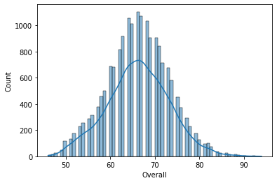

```python
sns.histplot(data=df, x='Overall', kde=True);
```

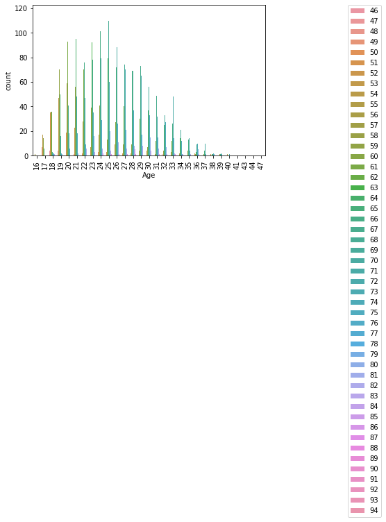

```python
sns.countplot(data=df, x='Age', hue='Overall');

plt.xticks(rotation=90)
plt.legend(bbox_to_anchor=(1.5, 1), borderaxespad=0)
```

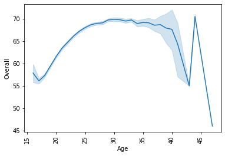

```python
sns.lineplot(data = df , x = 'Age' , y = 'Overall');
plt.xticks(rotation=90);
```

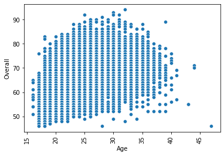

```python
sns.scatterplot(data=df, x='Age', y='Overall');
plt.xticks(rotation=90);
```

## Question 3:

Analysis of offensive players: Which type of offensive players tends to get paid the most: the striker, the right-winger, or the left-winger? Visualize through a scatter plot for all three. (6 points)

```python
df2=df.groupby(["ST", "RW", "LW"]).apply(lambda x:x['Wage'].mean()).reset_index(name='Means')
df2.sort_values(by='Means',ascending=False,inplace=True)
df2.head(10)
```

|  | ST | RW | LW | Means |
| --- | --- | --- | --- | --- |
| 919 | 92.0 | 91.0 | 91.0 | 565000.0 |
| 918 | 88.0 | 91.0 | 91.0 | 565000.0 |
| 917 | 88.0 | 87.0 | 87.0 | 510000.0 |
| 915 | 87.0 | 87.0 | 87.0 | 370000.0 |
| 916 | 88.0 | 84.0 | 84.0 | 355000.0 |
| 913 | 86.0 | 86.0 | 86.0 | 325000.0 |
| 903 | 83.0 | 83.0 | 83.0 | 295000.0 |
| 898 | 82.0 | 88.0 | 88.0 | 295000.0 |
| 890 | 81.0 | 85.0 | 85.0 | 285000.0 |
| 910 | 84.0 | 89.0 | 89.0 | 280000.0 |

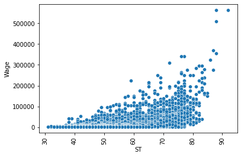

```python
sns.scatterplot(data=df, x='ST', y='Wage');
plt.xticks(rotation=90);
```

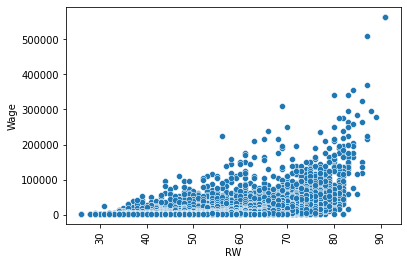

```python
sns.scatterplot(data=df, x='RW', y='Wage');
plt.xticks(rotation=90);
```

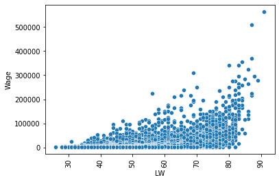

```python
sns.scatterplot(data=df, x='LW', y='Wage');
plt.xticks(rotation=90);
```

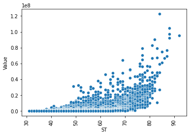

```python
sns.scatterplot(data=df, x='ST', y='Value');
plt.xticks(rotation=90);
```

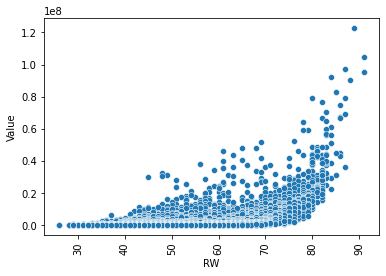

```python
sns.scatterplot(data=df, x='RW', y='Value');
plt.xticks(rotation=90);
```

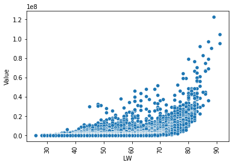

```python
sns.scatterplot(data=df, x='LW', y='Value');
plt.xticks(rotation=90);
```

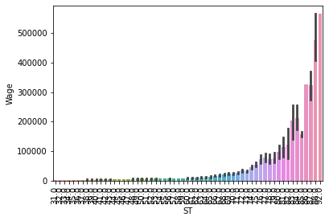

```python
sns.barplot(data=df, x="ST", y="Wage")
plt.xticks(rotation=90);
```

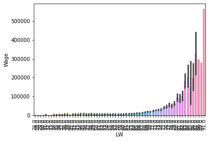

```python
sns.barplot(data=df, x="LW", y="Wage")
plt.xticks(rotation=90);
```

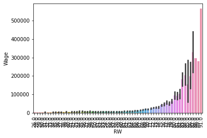

```python
sns.barplot(data=df, x="RW", y="Wage")
plt.xticks(rotation=90);
```

```python
dataFrame = pd.DataFrame(df, columns=["Wage", "ST", "RW","LW"])

dataFrame.plot(x="Wage", y=["ST","RW","LW"], kind="bar", figsize=(15, 15))
plt.xticks(rotation=90);

plt.show()
```

[output not shown]

## Question 4:

Best players for 2018: Top 5 players for every preferred position in terms of overall as well as potential points. Who were the best in 2018? (6 points)

```python
df2=df.groupby(["Name", "Potential","Overall"]).apply(lambda x:x['CAM'].count()).reset_index(name='Counts')
df2.sort_values(by='Counts',ascending=False,inplace=True)
df2.head(10)
```

|  | Name | Potential | Overall | Counts |
| --- | --- | --- | --- | --- |
| 388 | A. Costa | 74 | 74 | 2 |
| 16075 | S. Williams | 68 | 68 | 2 |
| 3003 | C. Pulisic | 89 | 78 | 2 |
| 13184 | O. Al Soma | 78 | 78 | 2 |
| 15348 | S. Dursun | 72 | 70 | 2 |
| 9354 | K. Mbodj | 80 | 78 | 2 |
| 15079 | RÃºben Semedo | 85 | 78 | 2 |
| 12071 | M. Sabitzer | 82 | 78 | 2 |
| 14087 | Pozuelo | 81 | 78 | 2 |
| 8663 | J. Vela | 72 | 68 | 2 |

```python
df2=df.groupby(["Name", "Potential","Overall"]).apply(lambda x:x['CB'].count()).reset_index(name='Counts')
df2.sort_values(by='Counts',ascending=False,inplace=True)
df2.head(10)
```

|  | Name | Potential | Overall | Counts |
| --- | --- | --- | --- | --- |
| 388 | A. Costa | 74 | 74 | 2 |
| 16075 | S. Williams | 68 | 68 | 2 |
| 3003 | C. Pulisic | 89 | 78 | 2 |
| 13184 | O. Al Soma | 78 | 78 | 2 |
| 15348 | S. Dursun | 72 | 70 | 2 |
| 9354 | K. Mbodj | 80 | 78 | 2 |
| 15079 | RÃºben Semedo | 85 | 78 | 2 |
| 12071 | M. Sabitzer | 82 | 78 | 2 |
| 14087 | Pozuelo | 81 | 78 | 2 |
| 8663 | J. Vela | 72 | 68 | 2 |

```python
df2=df.groupby(["Name", "Potential","Overall"]).apply(lambda x:x['CDM'].count()).reset_index(name='Counts')
df2.sort_values(by='Counts',ascending=False,inplace=True)
df2.head(10)
```

|  | Name | Potential | Overall | Counts |
| --- | --- | --- | --- | --- |
| 388 | A. Costa | 74 | 74 | 2 |
| 16075 | S. Williams | 68 | 68 | 2 |
| 3003 | C. Pulisic | 89 | 78 | 2 |
| 13184 | O. Al Soma | 78 | 78 | 2 |
| 15348 | S. Dursun | 72 | 70 | 2 |
| 9354 | K. Mbodj | 80 | 78 | 2 |
| 15079 | RÃºben Semedo | 85 | 78 | 2 |
| 12071 | M. Sabitzer | 82 | 78 | 2 |
| 14087 | Pozuelo | 81 | 78 | 2 |
| 8663 | J. Vela | 72 | 68 | 2 |

```python
df2=df.groupby(["Name", "Potential","Overall"]).apply(lambda x:x['CF'].count()).reset_index(name='Counts')
df2.sort_values(by='Counts',ascending=False,inplace=True)
df2.head(10)
```

|  | Name | Potential | Overall | Counts |
| --- | --- | --- | --- | --- |
| 388 | A. Costa | 74 | 74 | 2 |
| 16075 | S. Williams | 68 | 68 | 2 |
| 3003 | C. Pulisic | 89 | 78 | 2 |
| 13184 | O. Al Soma | 78 | 78 | 2 |
| 15348 | S. Dursun | 72 | 70 | 2 |
| 9354 | K. Mbodj | 80 | 78 | 2 |
| 15079 | RÃºben Semedo | 85 | 78 | 2 |
| 12071 | M. Sabitzer | 82 | 78 | 2 |
| 14087 | Pozuelo | 81 | 78 | 2 |
| 8663 | J. Vela | 72 | 68 | 2 |

```python
df2=df.groupby(["Name", "Potential","Overall"]).apply(lambda x:x['CM'].count()).reset_index(name='Counts')
df2.sort_values(by='Counts',ascending=False,inplace=True)
df2.head(10)
```

|  | Name | Potential | Overall | Counts |
| --- | --- | --- | --- | --- |
| 388 | A. Costa | 74 | 74 | 2 |
| 16075 | S. Williams | 68 | 68 | 2 |
| 3003 | C. Pulisic | 89 | 78 | 2 |
| 13184 | O. Al Soma | 78 | 78 | 2 |
| 15348 | S. Dursun | 72 | 70 | 2 |
| 9354 | K. Mbodj | 80 | 78 | 2 |
| 15079 | RÃºben Semedo | 85 | 78 | 2 |
| 12071 | M. Sabitzer | 82 | 78 | 2 |
| 14087 | Pozuelo | 81 | 78 | 2 |
| 8663 | J. Vela | 72 | 68 | 2 |

```python
df2=df.groupby(["Name", "Potential","Overall"]).apply(lambda x:x['LAM'].count()).reset_index(name='Counts')
df2.sort_values(by='Counts',ascending=False,inplace=True)
df2.head(10)
```

|  | Name | Potential | Overall | Counts |
| --- | --- | --- | --- | --- |
| 388 | A. Costa | 74 | 74 | 2 |
| 16075 | S. Williams | 68 | 68 | 2 |
| 3003 | C. Pulisic | 89 | 78 | 2 |
| 13184 | O. Al Soma | 78 | 78 | 2 |
| 15348 | S. Dursun | 72 | 70 | 2 |
| 9354 | K. Mbodj | 80 | 78 | 2 |
| 15079 | RÃºben Semedo | 85 | 78 | 2 |
| 12071 | M. Sabitzer | 82 | 78 | 2 |
| 14087 | Pozuelo | 81 | 78 | 2 |
| 8663 | J. Vela | 72 | 68 | 2 |

```python
df2=df.groupby(["Name", "Potential","Overall"]).apply(lambda x:x['LB'].count()).reset_index(name='Counts')
df2.sort_values(by='Counts',ascending=False,inplace=True)
df2.head(10)
```

|  | Name | Potential | Overall | Counts |
| --- | --- | --- | --- | --- |
| 388 | A. Costa | 74 | 74 | 2 |
| 16075 | S. Williams | 68 | 68 | 2 |
| 3003 | C. Pulisic | 89 | 78 | 2 |
| 13184 | O. Al Soma | 78 | 78 | 2 |
| 15348 | S. Dursun | 72 | 70 | 2 |
| 9354 | K. Mbodj | 80 | 78 | 2 |
| 15079 | RÃºben Semedo | 85 | 78 | 2 |
| 12071 | M. Sabitzer | 82 | 78 | 2 |
| 14087 | Pozuelo | 81 | 78 | 2 |
| 8663 | J. Vela | 72 | 68 | 2 |

```python
df2=df.groupby(["Name", "Potential","Overall"]).apply(lambda x:x['LCB'].count()).reset_index(name='Counts')
df2.sort_values(by='Counts',ascending=False,inplace=True)
df2.head(10)
```

|  | Name | Potential | Overall | Counts |
| --- | --- | --- | --- | --- |
| 388 | A. Costa | 74 | 74 | 2 |
| 16075 | S. Williams | 68 | 68 | 2 |
| 3003 | C. Pulisic | 89 | 78 | 2 |
| 13184 | O. Al Soma | 78 | 78 | 2 |
| 15348 | S. Dursun | 72 | 70 | 2 |
| 9354 | K. Mbodj | 80 | 78 | 2 |
| 15079 | RÃºben Semedo | 85 | 78 | 2 |
| 12071 | M. Sabitzer | 82 | 78 | 2 |
| 14087 | Pozuelo | 81 | 78 | 2 |
| 8663 | J. Vela | 72 | 68 | 2 |

```python
df2=df.groupby(["Name", "Potential","Overall"]).apply(lambda x:x['LCM'].count()).reset_index(name='Counts')
df2.sort_values(by='Counts',ascending=False,inplace=True)
df2.head(10)
```

|  | Name | Potential | Overall | Counts |
| --- | --- | --- | --- | --- |
| 388 | A. Costa | 74 | 74 | 2 |
| 16075 | S. Williams | 68 | 68 | 2 |
| 3003 | C. Pulisic | 89 | 78 | 2 |
| 13184 | O. Al Soma | 78 | 78 | 2 |
| 15348 | S. Dursun | 72 | 70 | 2 |
| 9354 | K. Mbodj | 80 | 78 | 2 |
| 15079 | RÃºben Semedo | 85 | 78 | 2 |
| 12071 | M. Sabitzer | 82 | 78 | 2 |
| 14087 | Pozuelo | 81 | 78 | 2 |
| 8663 | J. Vela | 72 | 68 | 2 |

```python
df2=df.groupby(["Name", "Potential","Overall"]).apply(lambda x:x['LDM'].count()).reset_index(name='Counts')
df2.sort_values(by='Counts',ascending=False,inplace=True)
df2.head(10)
```

|  | Name | Potential | Overall | Counts |
| --- | --- | --- | --- | --- |
| 388 | A. Costa | 74 | 74 | 2 |
| 16075 | S. Williams | 68 | 68 | 2 |
| 3003 | C. Pulisic | 89 | 78 | 2 |
| 13184 | O. Al Soma | 78 | 78 | 2 |
| 15348 | S. Dursun | 72 | 70 | 2 |
| 9354 | K. Mbodj | 80 | 78 | 2 |
| 15079 | RÃºben Semedo | 85 | 78 | 2 |
| 12071 | M. Sabitzer | 82 | 78 | 2 |
| 14087 | Pozuelo | 81 | 78 | 2 |
| 8663 | J. Vela | 72 | 68 | 2 |

```python
df2=df.groupby(["Name", "Potential","Overall"]).apply(lambda x:x['LF'].count()).reset_index(name='Counts')
df2.sort_values(by='Counts',ascending=False,inplace=True)
df2.head(10)
```

|  | Name | Potential | Overall | Counts |
| --- | --- | --- | --- | --- |
| 388 | A. Costa | 74 | 74 | 2 |
| 16075 | S. Williams | 68 | 68 | 2 |
| 3003 | C. Pulisic | 89 | 78 | 2 |
| 13184 | O. Al Soma | 78 | 78 | 2 |
| 15348 | S. Dursun | 72 | 70 | 2 |
| 9354 | K. Mbodj | 80 | 78 | 2 |
| 15079 | RÃºben Semedo | 85 | 78 | 2 |
| 12071 | M. Sabitzer | 82 | 78 | 2 |
| 14087 | Pozuelo | 81 | 78 | 2 |
| 8663 | J. Vela | 72 | 68 | 2 |

```python
df2=df.groupby(["Name", "Potential","Overall"]).apply(lambda x:x['LM'].count()).reset_index(name='Counts')
df2.sort_values(by='Counts',ascending=False,inplace=True)
df2.head(10)
```

|  | Name | Potential | Overall | Counts |
| --- | --- | --- | --- | --- |
| 388 | A. Costa | 74 | 74 | 2 |
| 16075 | S. Williams | 68 | 68 | 2 |
| 3003 | C. Pulisic | 89 | 78 | 2 |
| 13184 | O. Al Soma | 78 | 78 | 2 |
| 15348 | S. Dursun | 72 | 70 | 2 |
| 9354 | K. Mbodj | 80 | 78 | 2 |
| 15079 | RÃºben Semedo | 85 | 78 | 2 |
| 12071 | M. Sabitzer | 82 | 78 | 2 |
| 14087 | Pozuelo | 81 | 78 | 2 |
| 8663 | J. Vela | 72 | 68 | 2 |

```python
df2=df.groupby(["Name", "Potential","Overall"]).apply(lambda x:x['LS'].count()).reset_index(name='Counts')
df2.sort_values(by='Counts',ascending=False,inplace=True)
df2.head(10)
```

|  | Name | Potential | Overall | Counts |
| --- | --- | --- | --- | --- |
| 388 | A. Costa | 74 | 74 | 2 |
| 16075 | S. Williams | 68 | 68 | 2 |
| 3003 | C. Pulisic | 89 | 78 | 2 |
| 13184 | O. Al Soma | 78 | 78 | 2 |
| 15348 | S. Dursun | 72 | 70 | 2 |
| 9354 | K. Mbodj | 80 | 78 | 2 |
| 15079 | RÃºben Semedo | 85 | 78 | 2 |
| 12071 | M. Sabitzer | 82 | 78 | 2 |
| 14087 | Pozuelo | 81 | 78 | 2 |
| 8663 | J. Vela | 72 | 68 | 2 |

```python
df2=df.groupby(["Name", "Potential","Overall"]).apply(lambda x:x['LW'].count()).reset_index(name='Counts')
df2.sort_values(by='Counts',ascending=False,inplace=True)
df2.head(10)
```

|  | Name | Potential | Overall | Counts |
| --- | --- | --- | --- | --- |
| 388 | A. Costa | 74 | 74 | 2 |
| 16075 | S. Williams | 68 | 68 | 2 |
| 3003 | C. Pulisic | 89 | 78 | 2 |
| 13184 | O. Al Soma | 78 | 78 | 2 |
| 15348 | S. Dursun | 72 | 70 | 2 |
| 9354 | K. Mbodj | 80 | 78 | 2 |
| 15079 | RÃºben Semedo | 85 | 78 | 2 |
| 12071 | M. Sabitzer | 82 | 78 | 2 |
| 14087 | Pozuelo | 81 | 78 | 2 |
| 8663 | J. Vela | 72 | 68 | 2 |

```python
df2=df.groupby(["Name", "Potential","Overall"]).apply(lambda x:x['LWB'].count()).reset_index(name='Counts')
df2.sort_values(by='Counts',ascending=False,inplace=True)
df2.head(10)
```

|  | Name | Potential | Overall | Counts |
| --- | --- | --- | --- | --- |
| 388 | A. Costa | 74 | 74 | 2 |
| 16075 | S. Williams | 68 | 68 | 2 |
| 3003 | C. Pulisic | 89 | 78 | 2 |
| 13184 | O. Al Soma | 78 | 78 | 2 |
| 15348 | S. Dursun | 72 | 70 | 2 |
| 9354 | K. Mbodj | 80 | 78 | 2 |
| 15079 | RÃºben Semedo | 85 | 78 | 2 |
| 12071 | M. Sabitzer | 82 | 78 | 2 |
| 14087 | Pozuelo | 81 | 78 | 2 |
| 8663 | J. Vela | 72 | 68 | 2 |

```python
df2=df.groupby(["Name", "Potential","Overall"]).apply(lambda x:x['RAM'].count()).reset_index(name='Counts')
df2.sort_values(by='Counts',ascending=False,inplace=True)
df2.head(10)
```

|  | Name | Potential | Overall | Counts |
| --- | --- | --- | --- | --- |
| 388 | A. Costa | 74 | 74 | 2 |
| 16075 | S. Williams | 68 | 68 | 2 |
| 3003 | C. Pulisic | 89 | 78 | 2 |
| 13184 | O. Al Soma | 78 | 78 | 2 |
| 15348 | S. Dursun | 72 | 70 | 2 |
| 9354 | K. Mbodj | 80 | 78 | 2 |
| 15079 | RÃºben Semedo | 85 | 78 | 2 |
| 12071 | M. Sabitzer | 82 | 78 | 2 |
| 14087 | Pozuelo | 81 | 78 | 2 |
| 8663 | J. Vela | 72 | 68 | 2 |

```python
df2=df.groupby(["Name", "Potential","Overall"]).apply(lambda x:x['RB'].count()).reset_index(name='Counts')
df2.sort_values(by='Counts',ascending=False,inplace=True)
df2.head(10)
```

|  | Name | Potential | Overall | Counts |
| --- | --- | --- | --- | --- |
| 388 | A. Costa | 74 | 74 | 2 |
| 16075 | S. Williams | 68 | 68 | 2 |
| 3003 | C. Pulisic | 89 | 78 | 2 |
| 13184 | O. Al Soma | 78 | 78 | 2 |
| 15348 | S. Dursun | 72 | 70 | 2 |
| 9354 | K. Mbodj | 80 | 78 | 2 |
| 15079 | RÃºben Semedo | 85 | 78 | 2 |
| 12071 | M. Sabitzer | 82 | 78 | 2 |
| 14087 | Pozuelo | 81 | 78 | 2 |
| 8663 | J. Vela | 72 | 68 | 2 |

```python
df2=df.groupby(["Name", "Potential","Overall"]).apply(lambda x:x['RCB'].count()).reset_index(name='Counts')
df2.sort_values(by='Counts',ascending=False,inplace=True)
df2.head(10)
```

|  | Name | Potential | Overall | Counts |
| --- | --- | --- | --- | --- |
| 388 | A. Costa | 74 | 74 | 2 |
| 16075 | S. Williams | 68 | 68 | 2 |
| 3003 | C. Pulisic | 89 | 78 | 2 |
| 13184 | O. Al Soma | 78 | 78 | 2 |
| 15348 | S. Dursun | 72 | 70 | 2 |
| 9354 | K. Mbodj | 80 | 78 | 2 |
| 15079 | RÃºben Semedo | 85 | 78 | 2 |
| 12071 | M. Sabitzer | 82 | 78 | 2 |
| 14087 | Pozuelo | 81 | 78 | 2 |
| 8663 | J. Vela | 72 | 68 | 2 |

```python
df2=df.groupby(["Name", "Potential","Overall"]).apply(lambda x:x['RCM'].count()).reset_index(name='Counts')
df2.sort_values(by='Counts',ascending=False,inplace=True)
df2.head(10)
```

|  | Name | Potential | Overall | Counts |
| --- | --- | --- | --- | --- |
| 388 | A. Costa | 74 | 74 | 2 |
| 16075 | S. Williams | 68 | 68 | 2 |
| 3003 | C. Pulisic | 89 | 78 | 2 |
| 13184 | O. Al Soma | 78 | 78 | 2 |
| 15348 | S. Dursun | 72 | 70 | 2 |
| 9354 | K. Mbodj | 80 | 78 | 2 |
| 15079 | RÃºben Semedo | 85 | 78 | 2 |
| 12071 | M. Sabitzer | 82 | 78 | 2 |
| 14087 | Pozuelo | 81 | 78 | 2 |
| 8663 | J. Vela | 72 | 68 | 2 |

```python
df2=df.groupby(["Name", "Potential","Overall"]).apply(lambda x:x['RDM'].count()).reset_index(name='Counts')
df2.sort_values(by='Counts',ascending=False,inplace=True)
df2.head(10)
```

|  | Name | Potential | Overall | Counts |
| --- | --- | --- | --- | --- |
| 388 | A. Costa | 74 | 74 | 2 |
| 16075 | S. Williams | 68 | 68 | 2 |
| 3003 | C. Pulisic | 89 | 78 | 2 |
| 13184 | O. Al Soma | 78 | 78 | 2 |
| 15348 | S. Dursun | 72 | 70 | 2 |
| 9354 | K. Mbodj | 80 | 78 | 2 |
| 15079 | RÃºben Semedo | 85 | 78 | 2 |
| 12071 | M. Sabitzer | 82 | 78 | 2 |
| 14087 | Pozuelo | 81 | 78 | 2 |
| 8663 | J. Vela | 72 | 68 | 2 |

```python
df2=df.groupby(["Name", "Potential","Overall"]).apply(lambda x:x['RF'].count()).reset_index(name='Counts')
df2.sort_values(by='Counts',ascending=False,inplace=True)
df2.head(10)
```

|  | Name | Potential | Overall | Counts |
| --- | --- | --- | --- | --- |
| 388 | A. Costa | 74 | 74 | 2 |
| 16075 | S. Williams | 68 | 68 | 2 |
| 3003 | C. Pulisic | 89 | 78 | 2 |
| 13184 | O. Al Soma | 78 | 78 | 2 |
| 15348 | S. Dursun | 72 | 70 | 2 |
| 9354 | K. Mbodj | 80 | 78 | 2 |
| 15079 | RÃºben Semedo | 85 | 78 | 2 |
| 12071 | M. Sabitzer | 82 | 78 | 2 |
| 14087 | Pozuelo | 81 | 78 | 2 |
| 8663 | J. Vela | 72 | 68 | 2 |

```python
df2=df.groupby(["Name", "Potential","Overall"]).apply(lambda x:x['RM'].count()).reset_index(name='Counts')
df2.sort_values(by='Counts',ascending=False,inplace=True)
df2.head(10)
```

|  | Name | Potential | Overall | Counts |
| --- | --- | --- | --- | --- |
| 388 | A. Costa | 74 | 74 | 2 |
| 16075 | S. Williams | 68 | 68 | 2 |
| 3003 | C. Pulisic | 89 | 78 | 2 |
| 13184 | O. Al Soma | 78 | 78 | 2 |
| 15348 | S. Dursun | 72 | 70 | 2 |
| 9354 | K. Mbodj | 80 | 78 | 2 |
| 15079 | RÃºben Semedo | 85 | 78 | 2 |
| 12071 | M. Sabitzer | 82 | 78 | 2 |
| 14087 | Pozuelo | 81 | 78 | 2 |
| 8663 | J. Vela | 72 | 68 | 2 |

```python
df2=df.groupby(["Name", "Potential","Overall"]).apply(lambda x:x['RS'].count()).reset_index(name='Counts')
df2.sort_values(by='Counts',ascending=False,inplace=True)
df2.head(10)
```

|  | Name | Potential | Overall | Counts |
| --- | --- | --- | --- | --- |
| 388 | A. Costa | 74 | 74 | 2 |
| 16075 | S. Williams | 68 | 68 | 2 |
| 3003 | C. Pulisic | 89 | 78 | 2 |
| 13184 | O. Al Soma | 78 | 78 | 2 |
| 15348 | S. Dursun | 72 | 70 | 2 |
| 9354 | K. Mbodj | 80 | 78 | 2 |
| 15079 | RÃºben Semedo | 85 | 78 | 2 |
| 12071 | M. Sabitzer | 82 | 78 | 2 |
| 14087 | Pozuelo | 81 | 78 | 2 |
| 8663 | J. Vela | 72 | 68 | 2 |

```python
df2=df.groupby(["Name", "Potential","Overall"]).apply(lambda x:x['RW'].count()).reset_index(name='Counts')
df2.sort_values(by='Counts',ascending=False,inplace=True)
df2.head(10)
```

|  | Name | Potential | Overall | Counts |
| --- | --- | --- | --- | --- |
| 388 | A. Costa | 74 | 74 | 2 |
| 16075 | S. Williams | 68 | 68 | 2 |
| 3003 | C. Pulisic | 89 | 78 | 2 |
| 13184 | O. Al Soma | 78 | 78 | 2 |
| 15348 | S. Dursun | 72 | 70 | 2 |
| 9354 | K. Mbodj | 80 | 78 | 2 |
| 15079 | RÃºben Semedo | 85 | 78 | 2 |
| 12071 | M. Sabitzer | 82 | 78 | 2 |
| 14087 | Pozuelo | 81 | 78 | 2 |
| 8663 | J. Vela | 72 | 68 | 2 |

```python
df2=df.groupby(["Name", "Potential","Overall"]).apply(lambda x:x['RWB'].count()).reset_index(name='Counts')
df2.sort_values(by='Counts',ascending=False,inplace=True)
df2.head(10)
```

|  | Name | Potential | Overall | Counts |
| --- | --- | --- | --- | --- |
| 388 | A. Costa | 74 | 74 | 2 |
| 16075 | S. Williams | 68 | 68 | 2 |
| 3003 | C. Pulisic | 89 | 78 | 2 |
| 13184 | O. Al Soma | 78 | 78 | 2 |
| 15348 | S. Dursun | 72 | 70 | 2 |
| 9354 | K. Mbodj | 80 | 78 | 2 |
| 15079 | RÃºben Semedo | 85 | 78 | 2 |
| 12071 | M. Sabitzer | 82 | 78 | 2 |
| 14087 | Pozuelo | 81 | 78 | 2 |
| 8663 | J. Vela | 72 | 68 | 2 |

```python
df2=df.groupby(["Name", "Potential","Overall"]).apply(lambda x:x['ST'].count()).reset_index(name='Counts')
df2.sort_values(by='Counts',ascending=False,inplace=True)
df2.head(10)
```

|  | Name | Potential | Overall | Counts |
| --- | --- | --- | --- | --- |
| 388 | A. Costa | 74 | 74 | 2 |
| 16075 | S. Williams | 68 | 68 | 2 |
| 3003 | C. Pulisic | 89 | 78 | 2 |
| 13184 | O. Al Soma | 78 | 78 | 2 |
| 15348 | S. Dursun | 72 | 70 | 2 |
| 9354 | K. Mbodj | 80 | 78 | 2 |
| 15079 | RÃºben Semedo | 85 | 78 | 2 |
| 12071 | M. Sabitzer | 82 | 78 | 2 |
| 14087 | Pozuelo | 81 | 78 | 2 |
| 8663 | J. Vela | 72 | 68 | 2 |

```python
df2=df.groupby("Name").apply(lambda x:x['Overall'].count()).reset_index(name='Counts')
df2.sort_values(by='Counts',ascending=False,inplace=True)
df2.head(10)
```

|  | Name | Counts |
| --- | --- | --- |
| 8207 | J. Williams | 7 |
| 8143 | J. Valencia | 7 |
| 7954 | J. Rodríguez | 7 |
| 4136 | Danilo | 6 |
| 5470 | Felipe | 6 |
| 3509 | D. González | 6 |
| 7510 | J. Jones | 6 |
| 13230 | Paulinho | 6 |
| 16528 | Wanderson | 6 |
| 8245 | J. Álvarez | 5 |